# generate_UCH_metagenomics_plots

2026-03-05

A few of our samples did not sequence well and have very low trimmed read counts. We will remove those below 7 million reads before further analyzing mapping results.

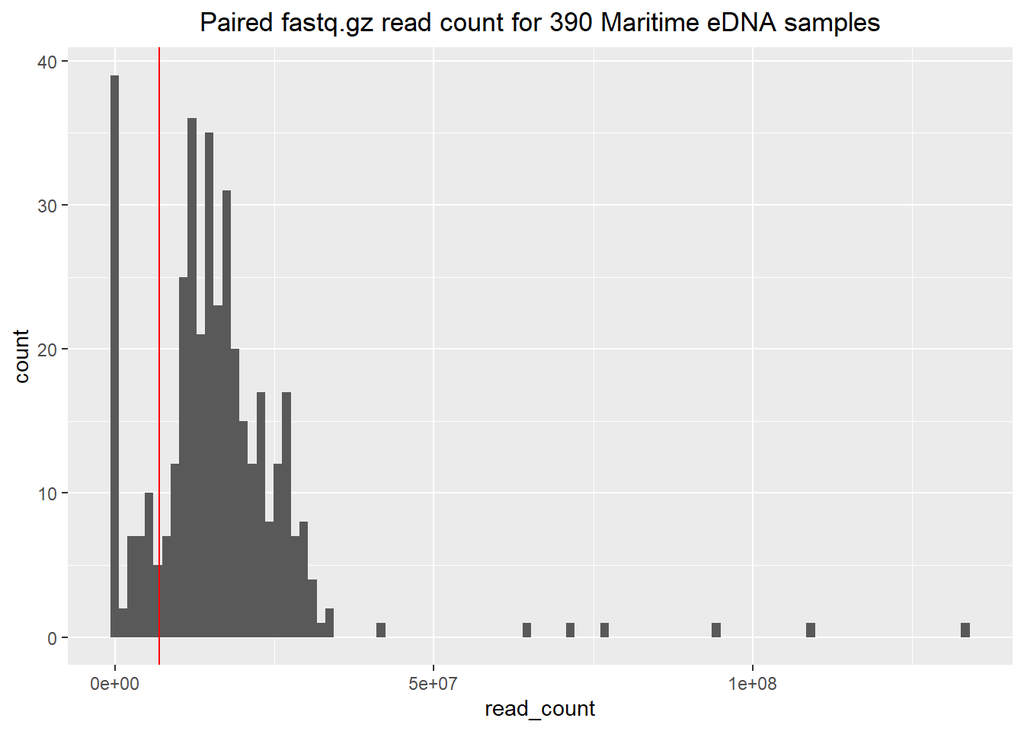

```r
#determine samples to keep
read_counts <- read.csv("data/read_counts.csv",header=F)
colnames(read_counts) <- c("sample","read_count")
ggplot(read_counts,aes(x=read_count))+geom_histogram(bins=100)+geom_vline(xintercept=7e6,color="red")+ggtitle("Paired fastq.gz read count for 390 Maritime eDNA samples")+theme(plot.title=element_text(hjust=0.5))
```

The file minimap2_coverage_and_abundance.csv contains the number of reads mapped for each sample-bin pair using minimap2 to a dRep dereplicated set. We have a set of samples associated with great lakes shipwrecks, but for this project we will focus on submerged aircrafts. Below, total_reads_mapped_per_base is a measurement of depth normalized by the total bin length and bins are of the form assemblier:Sampletype_Testbed_Site_Depth_Remains_GroupFlag_XCoordinate_YCoordinate:binnumber.

```r
metadata <- read.csv("data/all_metadata.csv")
abundance <- read.csv("data/minimap2_coverage_and_abundance.csv")
abundance <- abundance[abundance$run %in% read_counts[read_counts$read_count>7e6,"sample"],]
abundance <- abundance[!abundance$run %in% metadata[metadata$Testbed=="GreatLakes","SampleID"],]
head(abundance)
```

```
##            run                                                          bin
## 1 eDNA-2022-01    megahit:Sediment_GreatLakes_Corsican_48_0_A_1.2_1.2:bin.3
## 2 eDNA-2022-01 megahit:Sediment_GreatLakes_Corsican_48_0_B_4.89_4.89:bin.14
## 3 eDNA-2022-01 megahit:Sediment_GreatLakes_Corsican_48_0_B_4.89_4.89:bin.16
## 4 eDNA-2022-01 megahit:Sediment_GreatLakes_Corsican_48_0_B_4.89_4.89:bin.17
## 5 eDNA-2022-01 megahit:Sediment_GreatLakes_Corsican_48_0_B_4.89_4.89:bin.23
## 6 eDNA-2022-01 megahit:Sediment_GreatLakes_Corsican_48_0_B_4.89_4.89:bin.25
##   contig_count total_length total_reads_mapped reads_mapped_per_base   coverage
## 1         1058      3442476                501          1.455348e-04 0.24040836
## 2           89       691063                 48          6.945821e-05 0.09087449
## 3          631      1396577               1074          7.690231e-04 0.17306600
## 4            3       949181                252          2.654920e-04 0.22271832
## 5           74       857965                 12          1.398658e-05 0.02925527
## 6           14       970546                 77          7.933679e-05 0.13950910
```

We also have taxonomic classifications produced by the genome taxonomy database classifier that we will join with the mapping results.

```r
gtdbtk <- read.csv("data/gtdbtk.tsv",sep="\t")
gtdbtk <- gtdbtk[,c("user_genome","classification")]
gtdbtk$domain <- str_replace(str_split(gtdbtk$classification,";",simplify=TRUE)[,1],"d__","")
gtdbtk$phylum <- str_replace(str_split(gtdbtk$classification,";",simplify=TRUE)[,2],"p__","")
gtdbtk$class <- str_replace(str_split(gtdbtk$classification,";",simplify=TRUE)[,3],"c__","")
gtdbtk$order <- str_replace(str_split(gtdbtk$classification,";",simplify=TRUE)[,4],"o__","")
gtdbtk$family <- str_replace(str_split(gtdbtk$classification,";",simplify=TRUE)[,5],"f__","")
gtdbtk$genus <- str_replace(str_split(gtdbtk$classification,";",simplify=TRUE)[,6],"g__","")
gtdbtk$species <- str_replace(str_split(gtdbtk$classification,";",simplify=TRUE)[,7],"s__","")
gtdbtk <- gtdbtk[,colnames(gtdbtk)!="classification"]
head(gtdbtk)
```

```
##                                                     user_genome  domain
## 1      megahit:Sediment_GreatLakes_Corsican_48_0_F_0.86_0:bin.5 Archaea
## 2     megahit:Sediment_GreatLakes_Corsican_48_0_P_0_13.85:bin.5 Archaea
## 3        megahit:Sediment_GreatLakes_Norman_60_1_G_0.86_0:bin.6 Archaea
## 4      megahit:Sediment_GreatLakes_Norman_60_1_L_-1.2_1.2:bin.6 Archaea
## 5  megahit:Sediment_GreatLakes_Pewabic_50_1_AA_-4.89_4.89:bin.1 Archaea
## 6 megahit:Sediment_GreatLakes_Pewabic_50_1_AA_-4.89_4.89:bin.10 Archaea
##             phylum           class              order              family
## 1   Halobacteriota Methanomicrobia Methanomicrobiales   Methanoregulaceae
## 2 Thermoplasmatota  Thermoplasmata       RBG-16-68-12        RBG-16-68-12
## 3    Nanoarchaeota    Nanoarchaeia    Woesearchaeales               ARS49
## 4 Thermoplasmatota  Thermoplasmata       RBG-16-68-12        RBG-16-68-12
## 5   Halobacteriota Methanosarcinia  Methanosarcinales Methanoperedenaceae
## 6   Thermoproteota Nitrososphaeria  Nitrososphaerales   Nitrosopumilaceae
##             genus species
## 1   Methanoregula
## 2    RBG-16-68-12
## 3
## 4    RBG-16-68-12
## 5 Methanoperedens
## 6         UBA8516
```

```r
abundance <- abundance[,c("run","bin","reads_mapped_per_base","coverage")]
gtdbtk$bin <- gtdbtk$user_genome
abundance <- join(abundance,gtdbtk,by="bin")
```

To calculate relative abundance, we calculate the total reads_mapped_per_base for each sample, then normalize mapping depths by this value.

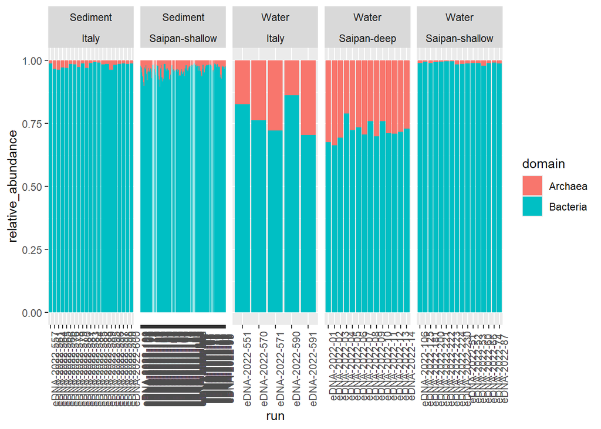

```r
total_reads_mapped_per_base <- data.frame(abundance%>%group_by(run)%>%summarize(total_reads_mapped_per_base=sum(reads_mapped_per_base)))
abundance <- join(abundance,total_reads_mapped_per_base,by="run")
abundance$relative_abundance <- abundance$reads_mapped_per_base/abundance$total_reads_mapped_per_base
total_abundance <- data.frame(abundance%>%group_by(run)%>%summarize(total_abundance=sum(relative_abundance)))
abundance <- abundance[abundance$run %in% total_abundance[!is.na(total_abundance$total_abundance),"run"],]
abundance$SampleID <- abundance$run
abundance <- join(abundance,metadata,by="SampleID")
ggplot(abundance,aes(y=relative_abundance,x=run,fill=domain))+geom_bar(stat="identity")+theme(axis.text.x=element_text(angle=90))+facet_grid(~Source+Testbed,scales="free")
```

Above we are just visualizing the relative proportions of bacteria and archaea in our samples. We ultimately want to color relative abundances by phylum, but by default there are too many unique phyla to get a clear visualization, so we will group less common phyla into the group “Other”. We will also decide on standard colours to use for each phylum.

```r
abundance[grepl("Desulfobacterota",abundance$phylum),"phylum"] <- "Desulfobacterota"
abundance[grepl("Myxococcota",abundance$phylum),"phylum"] <- "Myxococcota"


phylum_abundances <- data.frame(abundance%>%group_by(phylum)%>%summarize(total_abundance=sum(relative_abundance)))
phylum_abundances <- phylum_abundances[order(phylum_abundances$total_abundance,decreasing = TRUE),]
abundance$temp_phylum <- abundance$phylum
abundance[!abundance$temp_phylum %in% phylum_abundances[1:11,"phylum"],"temp_phylum"] <- "Other"


abundance$temp_phylum <- factor(abundance$temp_phylum,levels=c("Other","Bacteroidota","Cyanobacteriota","Myxococcota","Chloroflexota","Planctomycetota","Desulfobacterota","Acidobacteriota","Actinomycetota","Pseudomonadota","Thermoplasmatota","Thermoproteota"))

abundance$temp_testbed <- abundance$Testbed
abundance[abundance$Site=="Hellcat","temp_testbed"] <- "Saipan-shallow (Hellcat)"
abundance[abundance$Site=="Avenger","temp_testbed"] <- "Saipan-shallow (Avenger)"
abundance[abundance$Source=="Water" & abundance$Testbed=="Saipan-shallow","temp_testbed"] <- "Saipan-shallow"

phylum_colors <- c(Actinomycetota="dodgerblue2", Pseudomonadota="cornflowerblue",SAR324="royalblue4", Patescibacteria="khaki4",Cyanobacteriota="lightseagreen",Bacteroidota="turquoise",Nitrospirota="darkorange3",Planctomycetota="olivedrab",Other="gray",Gemmatimonadota="purple",`Thermoproteota`="gray20",Myxococcota="slateblue4",Methylomirabilota="brown",Thermoplasmatota="#2720b3",Chloroflexota="coral4","Acidobacteriota"="darkolivegreen",Desulfobacterota="seagreen4")
```

We can now make the first manuscript plot visualizing phylum relative abundances (unintuitively, figure 3).

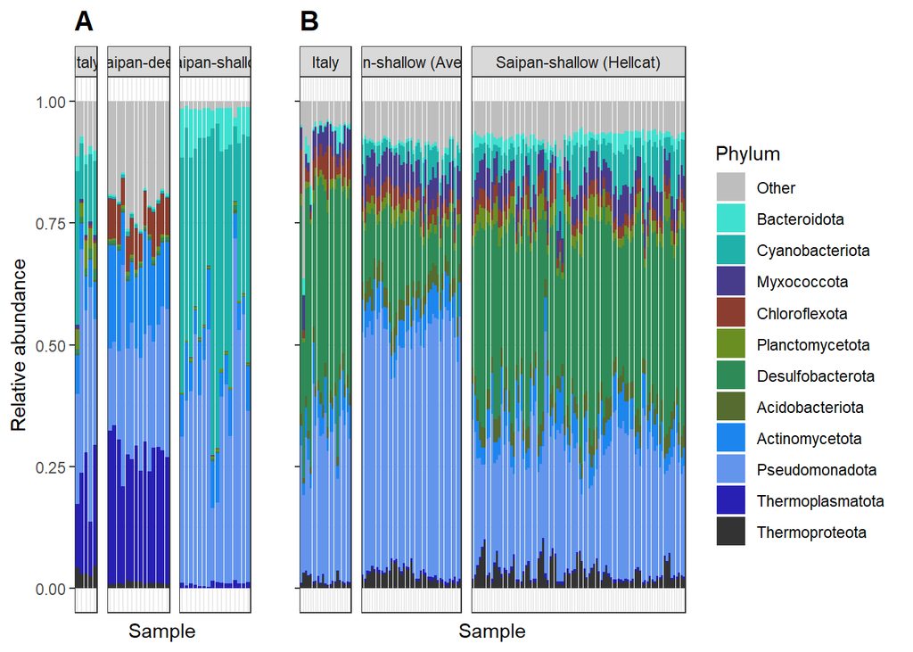

```r
figure_3_ab <- plot_grid(ggplot(abundance[abundance$Source=="Water",],aes(y=relative_abundance,x=run,fill=temp_phylum))+geom_bar(stat="identity")+theme(axis.text.x=element_text(angle=90))+facet_grid(~temp_testbed,scales="free",space="free")+scale_fill_manual(values = phylum_colors)+theme_bw()+theme(axis.text.x=element_blank(),axis.ticks.x = element_blank())+xlab("")+ylab("Relative abundance")+guides(fill=guide_legend(title="Phylum"))+ theme(legend.position="none")+ggtitle("Water")+xlab("Sample")+ggtitle("A")+ theme(plot.title = element_text(face="bold", size = 15)),
          ggplot(abundance[abundance$Source=="Sediment",],aes(y=relative_abundance,x=run,fill=temp_phylum))+geom_bar(stat="identity")+theme(axis.text.x=element_text(angle=90))+facet_grid(~temp_testbed,scales="free",space="free")+scale_fill_manual(values = phylum_colors)+theme_bw()+theme(axis.text.x=element_blank(),axis.ticks.x = element_blank())+xlab("")+ylab("")+xlab("Sample")+theme(axis.text.y=element_blank())+guides(fill=guide_legend(title="Phylum"))+ggtitle("B")+ theme(plot.title = element_text(face="bold", size = 15)),rel_widths=c(0.4,1))

ggsave("plots/Figure_3_AB.png",width=10.5,height=4,figure_3_ab)


figure_3_ab
```

We will first make a pca using the abundances of each unique phylum in each sample as input.

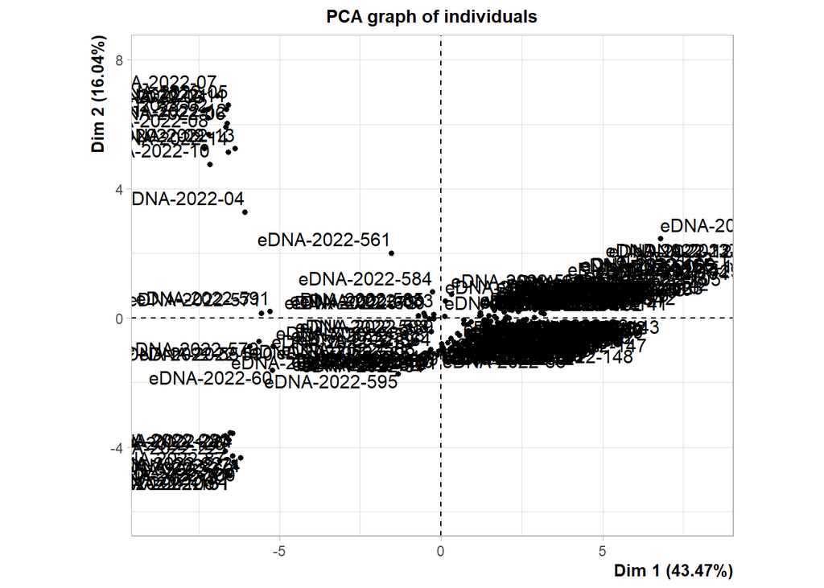

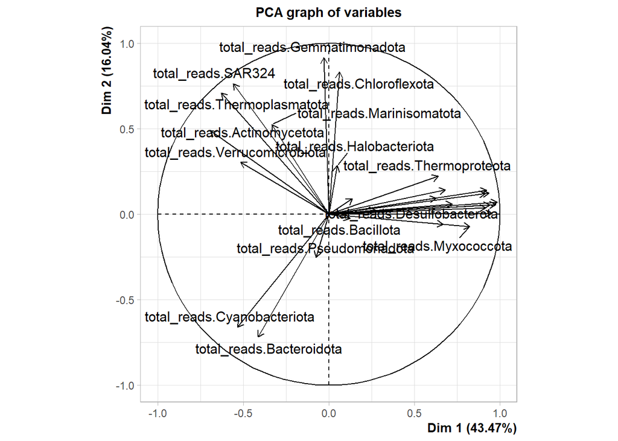

```r
abundance$key <- paste(abundance$run,abundance$phylum)
phylum_abundances <- data.frame(abundance%>%group_by(key)%>%summarize(total_reads=sum(relative_abundance)))
phylum_abundances$run <- str_split(phylum_abundances$key," ",simplify=TRUE)[,1]
phylum_abundances$phylum <- str_split(phylum_abundances$key," ",simplify=TRUE)[,2]

pca <- data.frame(reshape(phylum_abundances[,c("total_reads","run","phylum")], idvar = "run", timevar = "phylum", direction = "wide"))
rownames(pca) <- pca$run
pca <- pca[,colnames(pca)!="run"]
colnames(pca) <- str_replace(colnames(pca),"relative_abundance.","")
pca <- PCA(pca,scale.unit=TRUE,ncp=5,graph=TRUE)
```

Inspecting different metadata variables suggests that Testbed i.e. location and sample type are key determinants of clustering.

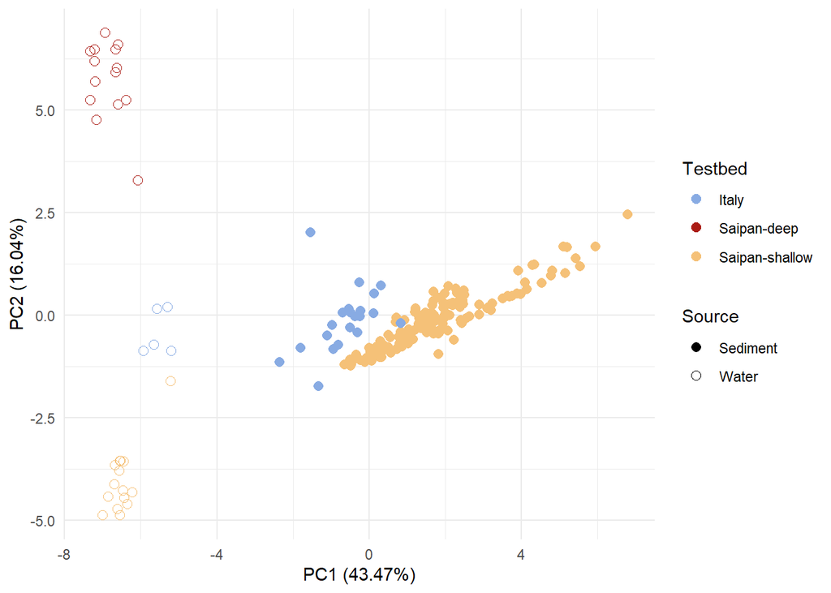

```r
pca_data <- data.frame(pca$ind$coord)
pca_data$SampleID <- rownames(pca_data)
pca_data <- join(pca_data,metadata,by="SampleID")

testbed_colors=c(Italy="#88abe3",`Saipan-shallow`="#f5c178",`Saipan-deep`="#ab1c15")

figure_2a <- ggplot(pca_data,aes(x=Dim.1,y=Dim.2,col=Testbed,shape=Source))+geom_point(size=2.5)+scale_shape_manual(values=c(16,1))+scale_color_manual(values=testbed_colors)+xlab(paste0("PC1 (",as.character(round(pca$eig[1,"percentage of variance"],2)),"%)"))+ylab(paste0("PC2 (",as.character(round(pca$eig[2,"percentage of variance"],2)),"%)"))+theme_minimal()

figure_2a
```

Since we have the phylum abundances calculated, let’s run some anosim comparisons using the R package vegan.

```r
phylum_abundances <- data.frame(reshape(phylum_abundances[,c("total_reads","run","phylum")], idvar = "run", timevar = "phylum", direction = "wide"))
rownames(phylum_abundances) <- phylum_abundances$run
phylum_abundances <- phylum_abundances[,colnames(phylum_abundances)!="run"]
colnames(phylum_abundances) <- str_replace(colnames(phylum_abundances),"total_reads.","")
com <- as.matrix(phylum_abundances)
rownames(metadata) <- metadata$SampleID
phylum_abundances <- cbind(phylum_abundances,metadata[rownames(phylum_abundances),])
ano = anosim(com, phylum_abundances$Source, distance = "bray", permutations = 9999)
ano
```

```
##
## Call:
## anosim(x = com, grouping = phylum_abundances$Source, permutations = 9999,      distance = "bray")
## Dissimilarity: bray
##
## ANOSIM statistic R: 0.946
##       Significance: 1e-04
##
## Permutation: free
## Number of permutations: 9999
```

There is a very significant difference between water and sediment samples, as we would expect from intuition and the visualizations.

```r
mysimper <- simper(com,phylum_abundances$Source,permutations = 9999)
mysimper
```

```
## cumulative contributions of most influential species:
##
## $Water_Sediment
## Desulfobacterota  Cyanobacteriota   Pseudomonadota Thermoplasmatota
##        0.2476172        0.4248004        0.5474736        0.6632292
##   Actinomycetota
##        0.7150668
```

The separation by sample type is most strongly influenced by Desulfobacterota, followed by Cyanobacteriota and Pseudomonadota. Note that the reported values are cumulative and we must subtract them to get individual phylum contributions.

```r
print(as.numeric(mysimper$Water_Sediment$cusum)[1])
```

```
## [1] 0.2476172
```

```r
for (val in seq(2,5)){
  print(as.numeric(mysimper$Water_Sediment$cusum)[val]-as.numeric(mysimper$Water_Sediment$cusum)[val-1])
}
```

```
## [1] 0.1771832
## [1] 0.1226732
## [1] 0.1157556
## [1] 0.05183757
```

You might have noticed in the above barplots that the saipan-deep water samples looked very different from the other water samples. Let’s quantify that differences:

```r
water_phylum_abundances <- phylum_abundances[phylum_abundances$Source=="Water",]
water_phylum_abundances$is_saipan_deep <- water_phylum_abundances$Testbed=="Saipan-deep"
anosim(com[rownames(water_phylum_abundances),], water_phylum_abundances$is_saipan_deep, distance = "bray", permutations = 9999)
```

```
##
## Call:
## anosim(x = com[rownames(water_phylum_abundances), ], grouping = water_phylum_abundances$is_saipan_deep,      permutations = 9999, distance = "bray")
## Dissimilarity: bray
##
## ANOSIM statistic R: 0.9083
##       Significance: 1e-04
##
## Permutation: free
## Number of permutations: 9999
```

```r
simper(com[rownames(water_phylum_abundances),], water_phylum_abundances$is_saipan_deep, permutations = 9999)
```

```
## cumulative contributions of most influential species:
##
## $TRUE_FALSE
##  Cyanobacteriota Thermoplasmatota   Pseudomonadota           SAR324
##        0.2989831        0.4832638        0.6285192        0.7241699
```

Let’s see how the pca visualization changes when individual MAGs, not phyla, are used as input.

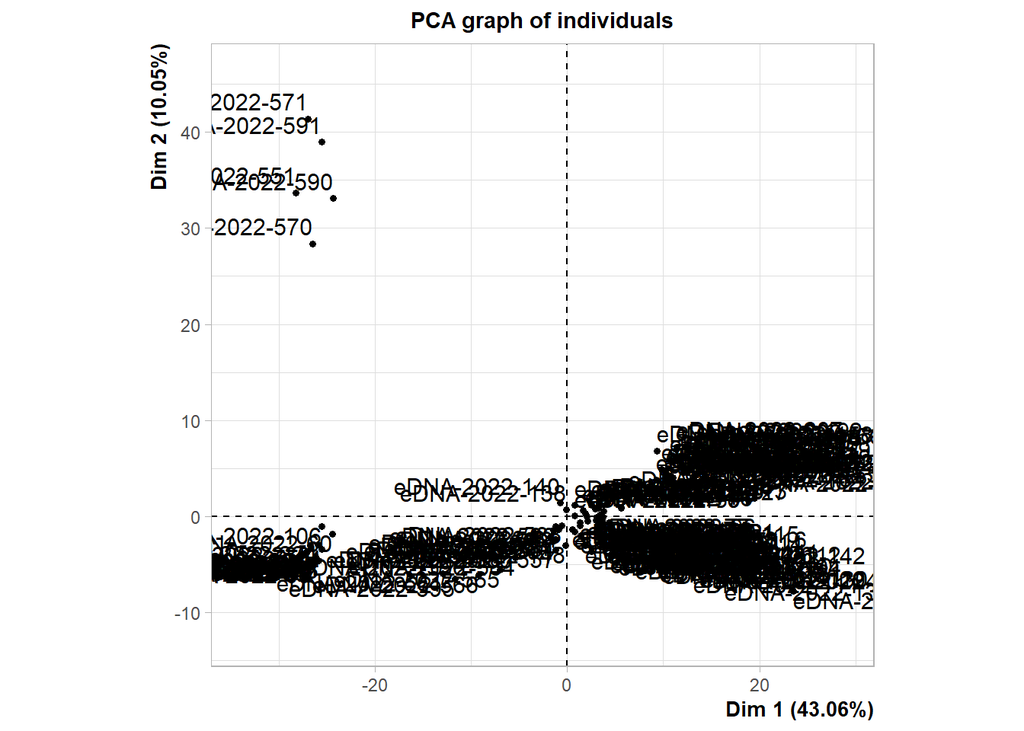

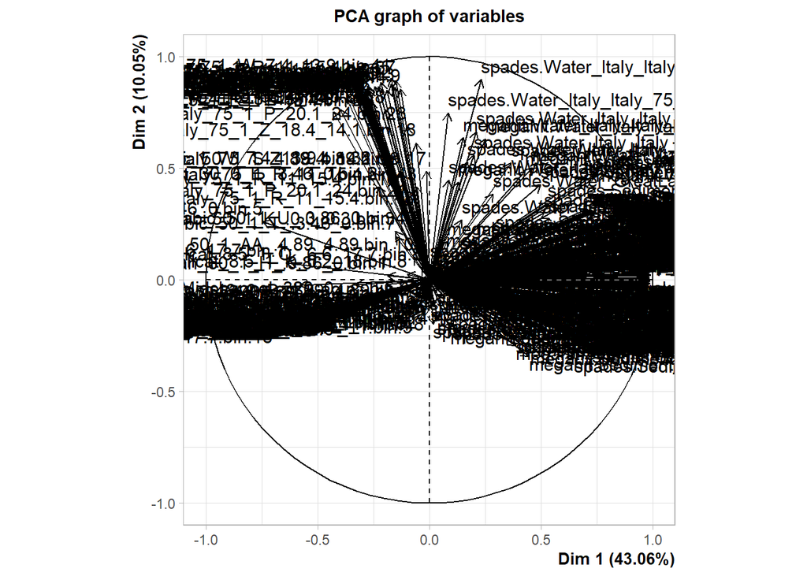

```r
pca <- data.frame(reshape(abundance[,c("relative_abundance","run","bin")], idvar = "run", timevar = "bin", direction = "wide"))
rownames(pca) <- pca$run
pca <- pca[,colnames(pca)!="run"]
colnames(pca) <- str_replace(colnames(pca),"relative_abundance.","")
pca <- PCA(pca,scale.unit=TRUE,ncp=5,graph=TRUE)
```

```r
pca_bin_contribs <- data.frame(pca$var$contrib)
```

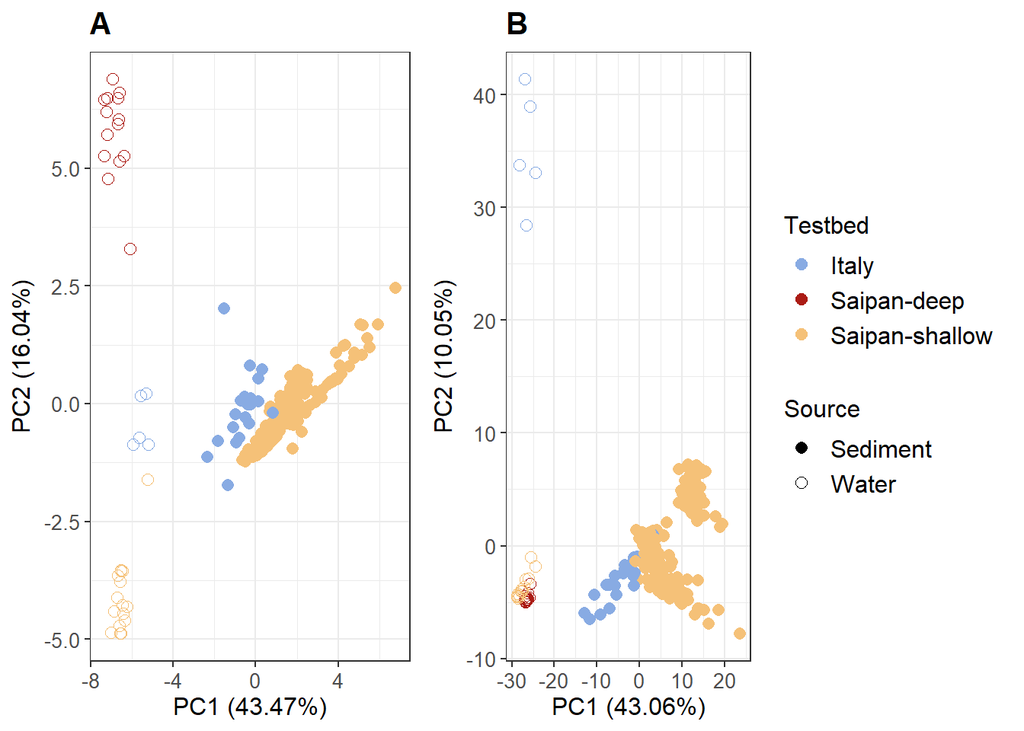

```r
pca_data <- data.frame(pca$ind$coord)
pca_data$SampleID <- rownames(pca_data)
pca_data <- join(pca_data,metadata,by="SampleID")

figure_2b <- ggplot(pca_data,aes(x=Dim.1,y=Dim.2,col=Testbed,shape=Source))+geom_point(size=2.5)+scale_shape_manual(values=c(16,1))+scale_color_manual(values=testbed_colors)+xlab(paste0("PC1 (",as.character(round(pca$eig[1,"percentage of variance"],2)),"%)"))+ylab(paste0("PC2 (",as.character(round(pca$eig[2,"percentage of variance"],2)),"%)"))+theme_bw()

figure_2 <- plot_grid(figure_2a+theme_bw()+theme(legend.position="none")+ggtitle("A")+ theme(plot.title = element_text(face="bold", size = 15),axis.text.x=element_text(size=10),axis.title.x=element_text(size=12),axis.text.y=element_text(size=10),axis.title.y=element_text(size=12)),figure_2b+ggtitle("B")+ theme(plot.title = element_text(face="bold", size = 15),axis.text.x=element_text(size=10),axis.title.x=element_text(size=12),axis.text.y=element_text(size=10),axis.title.y=element_text(size=12),legend.text=element_text(size=12),legend.title=element_text(size=12)),rel_widths=c(0.7,1))

ggsave("plots/Figure_2.png",figure_2,width=10,height=5,bg="white")
figure_2
```

Using individual MAGs as input results in substantial separation of Italy water bins across the second principal component. The two distinct blobs of Saipan-shallow sediment samples in figure B also correspond to the Hellcat and Avenger sites.

```r
mag_abundances <- data.frame(reshape(abundance[,c("relative_abundance","run","bin")], idvar = "run", timevar = "bin", direction = "wide"))
rownames(mag_abundances) <- mag_abundances$run
mag_abundances <- mag_abundances[,colnames(mag_abundances)!="run"]
colnames(mag_abundances) <- str_replace(colnames(mag_abundances),"relative_abundance.","")
com <- as.matrix(mag_abundances)
rownames(metadata) <- metadata$SampleID
mag_abundances <- cbind(mag_abundances,metadata[rownames(mag_abundances),])
mag_abundances$is_odd <- mag_abundances$Source=="Water" & mag_abundances$Testbed=="Italy"
mag_abundances[mag_abundances$is_odd,"is_odd"] <- "Italy_water"

mag_abundances$is_Italy <- mag_abundances$Testbed=="Italy"
anosim(com[rownames(mag_abundances[mag_abundances$Source=="Water",]),], mag_abundances[mag_abundances$Source=="Water","is_Italy"], distance = "bray", permutations = 9999)
```

```
##
## Call:
## anosim(x = com[rownames(mag_abundances[mag_abundances$Source ==      "Water", ]), ], grouping = mag_abundances[mag_abundances$Source ==      "Water", "is_Italy"], permutations = 9999, distance = "bray")
## Dissimilarity: bray
##
## ANOSIM statistic R: 0.3932
##       Significance: 1e-04
##
## Permutation: free
## Number of permutations: 9999
```

```r
for (col in colnames(phylum_abundances)){
  if (col %in% gtdbtk$phylum){
    phylum_abundances[,col] <- as.numeric(phylum_abundances[,col])
  }
}
com <- as.matrix(phylum_abundances[,!colnames(phylum_abundances) %in% colnames(metadata) & colnames(phylum_abundances)!="is_Italy"])
phylum_abundances$is_Italy <- phylum_abundances$Testbed=="Italy"
anosim(com[rownames(phylum_abundances[phylum_abundances$Source=="Water",]),], phylum_abundances[phylum_abundances$Source=="Water","is_Italy"], distance = "bray", permutations = 9999)
```

```
##
## Call:
## anosim(x = com[rownames(phylum_abundances[phylum_abundances$Source ==      "Water", ]), ], grouping = phylum_abundances[phylum_abundances$Source ==      "Water", "is_Italy"], permutations = 9999, distance = "bray")
## Dissimilarity: bray
##
## ANOSIM statistic R: -0.02742
##       Significance: 0.6528
##
## Permutation: free
## Number of permutations: 9999
```

The Italy water samples differ substantially from other water samples, but only when MAGs (not phyla) are used as input to ANOSIM. Let’s determine which specific MAGs are leading to this difference by leveraging the second principal component where the Italy samples are separated.

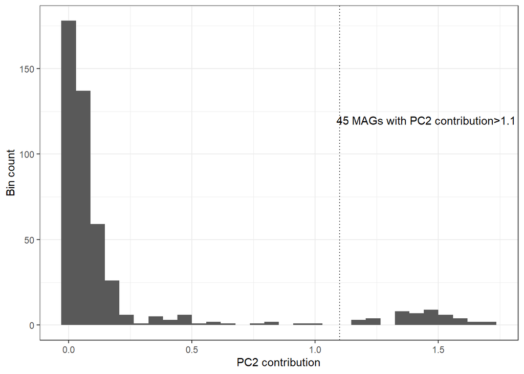

```r
figure_s2 <- ggplot(pca_bin_contribs,aes(x=Dim.2))+geom_histogram()+geom_vline(xintercept=1.1,linetype="dotted")+theme_bw()+xlab("PC2 contribution")+ylab("Bin count") +annotate("text", x = 1.45, y = 120, label = "45 MAGs with PC2 contribution>1.1")
ggsave("plots/figure_s2.png",figure_s2,height=5,width=8)
figure_s2
```

The top peak of PC2 contributions contains 45 bins:

```r
odd_bins <- str_replace(str_replace(rownames(pca_bin_contribs[pca_bin_contribs$Dim.2>1.1,]),fixed("."),":"),".bin",":bin")
length(odd_bins)
```

```
## [1] 45
```

```r
odd_bins
```

```
##  [1] "megahit:Water_Italy_Italy_75_1_P_20.1_24:bin.13"
##  [2] "megahit:Water_Italy_Italy_75_1_P_20.1_24:bin.19"
##  [3] "megahit:Water_Italy_Italy_75_1_R_11_15.4:bin.14"
##  [4] "megahit:Water_Italy_Italy_75_1_R_11_15.4:bin.23"
##  [5] "megahit:Water_Italy_Italy_75_1_R_11_15.4:bin.37"
##  [6] "megahit:Water_Italy_Italy_75_1_R_11_15.4:bin.9"
##  [7] "megahit:Water_Italy_Italy_75_1_W_7.4_13.9:bin.15"
##  [8] "megahit:Water_Italy_Italy_75_1_W_7.4_13.9:bin.20"
##  [9] "megahit:Water_Italy_Italy_75_1_W_7.4_13.9:bin.24"
## [10] "megahit:Water_Italy_Italy_75_1_W_7.4_13.9:bin.33"
## [11] "megahit:Water_Italy_Italy_75_1_W_7.4_13.9:bin.35"
## [12] "megahit:Water_Italy_Italy_75_1_W_7.4_13.9:bin.36"
## [13] "megahit:Water_Italy_Italy_75_1_Z_18.4_14.1:bin.19"
## [14] "megahit:Water_Italy_Italy_75_1_Z_18.4_14.1:bin.8"
## [15] "megahit:Water_Italy_Italy_75_1_Z_18.4_14.1:bin.9"
```

[output cut: 30 more lines]

We can produce a quick visualization of these bins’ relative abundance to add to figure 3:

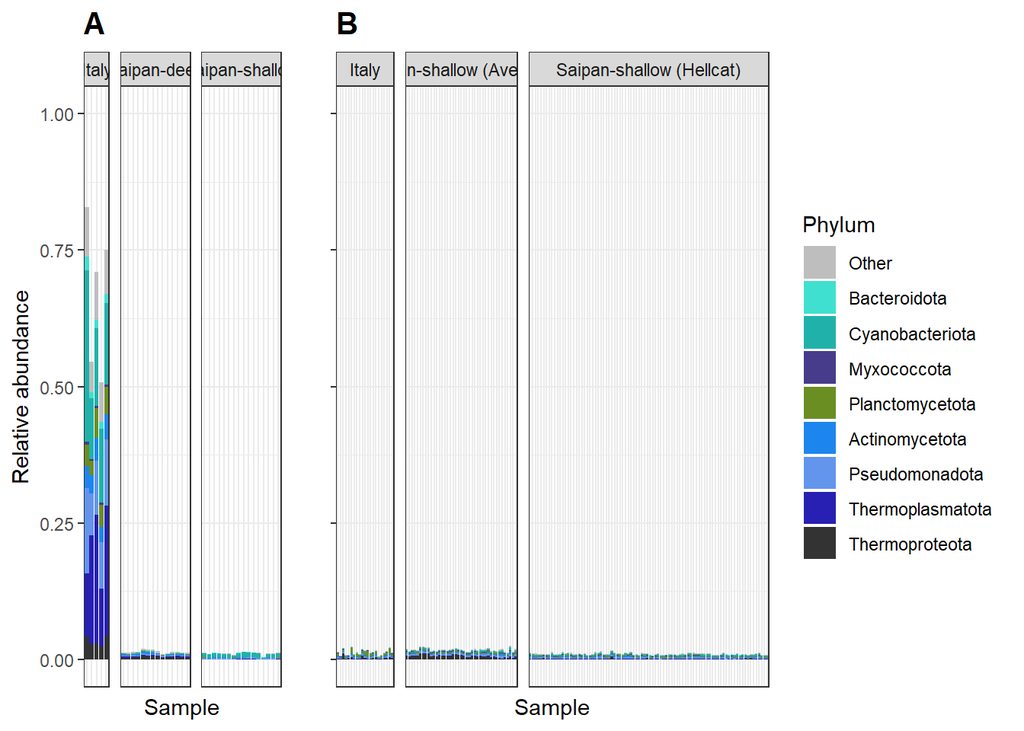

```r
figure_3_cd <- plot_grid(ggplot(abundance[abundance$Source=="Water" & abundance$bin %in% odd_bins,],aes(y=relative_abundance,x=run,fill=temp_phylum))+theme_bw()+ylim(0,1)+geom_bar(stat="identity")+theme(axis.text.x=element_text(angle=90))+facet_grid(~temp_testbed,scales="free",space="free")+scale_fill_manual(values = phylum_colors)+theme(axis.text.x=element_blank(),axis.ticks.x = element_blank())+xlab("")+ylab("Relative abundance")+guides(fill=guide_legend(title="Phylum"))+ theme(legend.position="none")+ggtitle("Water")+xlab("Sample")+ggtitle("A")+ theme(plot.title = element_text(face="bold", size = 15)),
          ggplot(abundance[abundance$Source=="Sediment" &  abundance$bin %in% odd_bins,],aes(y=relative_abundance,x=run,fill=temp_phylum))+geom_bar(stat="identity")+theme_bw()+theme(axis.text.x=element_text(angle=90))+facet_grid(~temp_testbed,scales="free",space="free")+ylim(0,1)+scale_fill_manual(values = phylum_colors)+theme(axis.text.x=element_blank(),axis.ticks.x = element_blank())+xlab("")+ylab("")+xlab("Sample")+theme(axis.text.y=element_blank())+guides(fill=guide_legend(title="Phylum"))+ggtitle("B")+ theme(plot.title = element_text(face="bold", size = 15)),rel_widths=c(0.4,1))
ggsave("plots/Figure_3_CD.png",width=10.5,height=4,figure_3_cd)
figure_3_cd
```

We can use simple fisher tests to compare the eggnog coding potential of these MAGs to the rest of the dataset. This requires a bit of manipulation to get the eggnog kegg annotations into a suitable format for enrichment analysis.

```r
#Using an excel converted version of the file because R sometimes has trouble reading in very long tsvs
eggnog <- read_xlsx("data/emapper.annotations.xlsx")
eggnog$bin <- paste(str_split(eggnog$query,"_",simplify=TRUE)[,1],str_split(eggnog$query,"_",simplify=TRUE)[,2],str_split(eggnog$query,"_",simplify=TRUE)[,3],str_split(eggnog$query,"_",simplify=TRUE)[,4],str_split(eggnog$query,"_",simplify=TRUE)[,5],str_split(eggnog$query,"_",simplify=TRUE)[,6],str_split(eggnog$query,"_",simplify=TRUE)[,7],str_split(eggnog$query,"_",simplify=TRUE)[,8],sep="_")
eggnog <- data.frame(eggnog)

#get a matrix of how often each kegg id occurs in each MAG
kegg <- eggnog[,c("query","KEGG_ko")]
kegg <- kegg[kegg$KEGG_ko!="-",]
kegg <- kegg[!is.na(kegg$KEGG_ko),]
kegg <- kegg[kegg$KEGG_ko!="",]
kegg <- data.table(kegg)
kegg <- kegg[, list(kegg_hit = unlist(strsplit(KEGG_ko , ","))),by=query]
kegg <- data.frame(kegg)
kegg$group <- paste(str_split(kegg$query,":",simplify=TRUE)[,1],str_split(kegg$query,":",simplify=TRUE)[,2],sep=".")
kegg$bin <- str_split(str_split(kegg$query,":",simplify=TRUE)[,3],"_",simplify=TRUE)[,1]
kegg$bin <- paste(kegg$group,kegg$bin,sep=".")
kegg <- distinct(kegg[,c("bin","kegg_hit")])
colnames(kegg) <- c("fasta","kegg_hit")
kegg$key <- paste(kegg$fasta,kegg$kegg_hit,sep=";")
kegg_counts <- data.frame(table(kegg$key))
kegg_counts$bin <- str_split(kegg_counts$Var1,";",simplify=TRUE)[,1]
kegg_counts$kegg <- str_split(kegg_counts$Var1,";",simplify=TRUE)[,2]
temp <- data.frame(table(kegg_counts$kegg))
kegg_counts <- kegg_counts[kegg_counts$kegg %in% temp[temp$Freq>5,"Var1"],]
kegg_counts <- data.frame(reshape(kegg_counts[,c("bin","kegg","Freq")],idvar = "bin", timevar = "kegg", direction = "wide"))
rownames(kegg_counts) <- kegg_counts$bin
kegg_counts <- kegg_counts[,colnames(kegg_counts)!="bin"]
colnames(kegg_counts) <- str_replace_all(colnames(kegg_counts),"Freq.","")
kegg_counts[is.na(kegg_counts)] <- 0

kegg_counts <- data.frame(t(kegg_counts))
```

```r
#get matrix of how often each kegg id occurs in each clade (Italy or other)
clades <- list()
clades[["Italy_75"]] <- str_replace_all(odd_bins,":",".")
clades[["outgroup"]] <- colnames(kegg_counts)[!colnames(kegg_counts) %in% clades[["Italy_75"]]]


all_counts <- list()
for (clade in names(clades)){

  clade_counts <- kegg_counts[,clades[[clade]]]
  clade_counts$sum <- apply(clade_counts,1,sum)
  clade_counts$bins_with_kegg <- ncol(clade_counts)-1-clade_counts$sum
  all_counts[[clade]] <- clade_counts[,c("sum","bins_with_kegg")]
  all_counts[[clade]]$kegg <- rownames(clade_counts)

}
all_counts <- ldply(all_counts)
colnames(all_counts) <- c("bin_group","bins_with_kegg","bins_without_kegg","kegg")
```

Now we can run fisher tests.

```r
all_fisher_results <- list()

get_fold_change <- function(x){
  x <- as.numeric(x)
  return(x[1]/(x[1]+x[2])/(x[3]/(x[3]+x[4])))

}

for (clade in names(clades)){

  within_clade_counts <- all_counts[all_counts$bin_group==clade,]
  outside_clade_counts <- all_counts[all_counts$bin_group!=clade,]

  rownames(outside_clade_counts) <- outside_clade_counts$kegg
  rownames(within_clade_counts) <- within_clade_counts$kegg
  outside_clade_counts <- outside_clade_counts[rownames(within_clade_counts),]
  clade_counts <- cbind(within_clade_counts[,c("bins_with_kegg","bins_without_kegg")],outside_clade_counts[,c("bins_with_kegg","bins_without_kegg")])
  colnames(clade_counts) <- c("ingroup_with_kegg","ingroup_without_kegg","outgroup_with_kegg","outgroup_without_kegg")
p_values <- apply(clade_counts,1, function(x) fisher.test(matrix(x,nr=2))$p.value)
fold_changes <- log2(apply(clade_counts,1,get_fold_change))
#fisher_results <- fisher_results[[clade]]
fisher_results <- clade_counts
fisher_results$fold_change <- fold_changes
fisher_results$p_value <- p_values
#fisher_results <- data.frame(rownames(within_clade_counts),fold_changes,p_values)
#colnames(fisher_results) <- c("orthogroup","fold_change","p_value")
fisher_results[is.nan(fisher_results$fold_change),"fold_change"] <- 0
fisher_results[is.infinite(fisher_results$fold_change) & fisher_results$fold_change < 0,"fold_change"] <- min(fisher_results[!is.infinite(fisher_results$fold_change),"fold_change"],na.rm = TRUE)
fisher_results[is.infinite(fisher_results$fold_change) & fisher_results$fold_change > 0,"fold_change"] <- max(fisher_results[!is.infinite(fisher_results$fold_change),"fold_change"],na.rm = TRUE)
fisher_results$p_adjust <- p.adjust(fisher_results$p_value, method = 'hochberg', n = nrow(fisher_results))
 fisher_results <- fisher_results[order(fisher_results$p_value),]
 fisher_results$kegg <- rownames(fisher_results)
all_fisher_results[[clade]] <- fisher_results
print(clade)

  }
```

```
## [1] "Italy_75"
## [1] "outgroup"
```

```r
all_fisher_results <- ldply(all_fisher_results)
all_fisher_results <- all_fisher_results[all_fisher_results$.id=="Italy_75",]
all_fisher_results <- all_fisher_results[all_fisher_results$p_adjust<=0.05,]
all_fisher_results <- all_fisher_results[order(all_fisher_results$fold_change),]
```

```r
head(all_fisher_results)
```

```
##         .id ingroup_with_kegg ingroup_without_kegg outgroup_with_kegg
## 17 Italy_75                 1                   44                165
## 25 Italy_75                 0                   45                128
## 39 Italy_75                 0                   45                118
## 40 Italy_75                 0                   45                118
## 49 Italy_75                 0                   45                117
## 60 Italy_75                 0                   45                115
##    outgroup_without_kegg fold_change      p_value     p_adjust      kegg
## 17                   265   -4.109982 7.241641e-08 0.0004306604 ko.K06990
## 25                   302   -4.109982 4.911071e-07 0.0029166852 ko.K13924
## 39                   312   -4.109982 1.916150e-06 0.0113512755 ko.K03388
## 40                   312   -4.109982 1.916150e-06 0.0113512755 ko.K04767
## 49                   313   -4.109982 1.975592e-06 0.0116856295 ko.K09181
## 60                   315   -4.109982 3.715081e-06 0.0219338408 ko.K00425
```

```r
kegg_names <- read.table("data/ko00001.keg",fill=TRUE)
kegg_names <- kegg_names[kegg_names$V1 %in% c("A","B","C","D"),]
kegg_names$name <- paste(kegg_names$V3,kegg_names$V4,kegg_names$V5,kegg_names$V6)
kegg_names$kegg <- kegg_names$V2
kegg_names <- kegg_names[,c("kegg","name")]
all_fisher_results$kegg <- str_replace(all_fisher_results$kegg,"ko.","")
all_fisher_results <- plyr::join(all_fisher_results,kegg_names,by="kegg")

all_fisher_results <- distinct(all_fisher_results)
all_fisher_results <- all_fisher_results[order(all_fisher_results$p_value),]
write.csv(all_fisher_results,"data/italy_fisher_results.csv")
```

Let’s move on to alkane metabolism occurring in sediment sites.

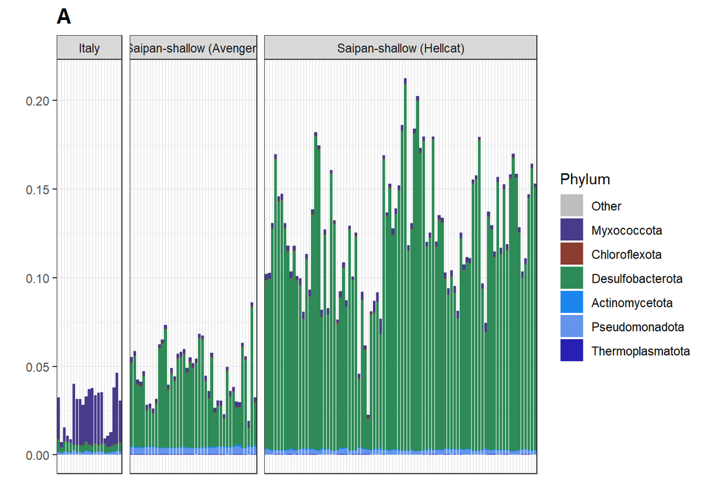

```r
figure_4a <- ggplot(abundance[abundance$Source=="Sediment" & abundance$bin %in% eggnog[grepl("Alkane 1-monooxygenase",eggnog$Description),"bin"],],aes(y=relative_abundance,x=run,fill=temp_phylum))+
  geom_bar(stat="identity")+theme(axis.text.x=element_text(angle=90))+facet_grid(~temp_testbed,scales="free",space="free")+
  theme_bw()+scale_fill_manual(values = phylum_colors)+theme(axis.text.x=element_blank(),axis.ticks.x = element_blank())+xlab("")+ylab("")+ggtitle("A")+ theme(plot.title = element_text(face="bold", size = 15))+guides(fill=guide_legend(title="Phylum"))
ggsave("plots/Figure_4a.png",figure_4a+ylab("Relative abundance"),height=3,width=8,dpi=500)
figure_4a
```

For visualizing the full alkane degradation pathway, I am reading in a list of relevant kos that we will visualize for desulfobacterota at the hellcat site using pathview.

```r
to_join <- data.frame(eggnog[,c("bin","KEGG_ko")]%>%separate_longer_delim(delim=",",cols="KEGG_ko"))

target_kos <- read.csv("data/fatty_acid_kos.txt.txt",header=F)

grouped_hellcat_abundances <- join(abundance[abundance$Site=="Hellcat" & abundance$Source=="Sediment" & abundance$phylum=="Desulfobacterota",],to_join[to_join$KEGG_ko %in% target_kos$V1,c("bin","KEGG_ko")],by="bin")
grouped_hellcat_abundances <- distinct(grouped_hellcat_abundances[,c("run","bin","KEGG_ko","relative_abundance")])
grouped_hellcat_abundances <- data.frame(grouped_hellcat_abundances%>%group_by(KEGG_ko)%>%summarize(total_abundance=sum(relative_abundance)))
grouped_hellcat_abundances$total_abundance <- grouped_hellcat_abundances$total_abundance/nrow(metadata[metadata$Site=="Hellcat" & metadata$Source=="Sediment",])#normalize total abundances by total number of hellcat sediment runs to get average abundance of bins containing each ko
grouped_hellcat_abundances <- grouped_hellcat_abundances[!is.na(grouped_hellcat_abundances$KEGG_ko),]
temp <- str_replace(grouped_hellcat_abundances$KEGG_ko,"ko:","")
grouped_hellcat_abundances <- grouped_hellcat_abundances$total_abundance
names(grouped_hellcat_abundances) <- temp


pv.out <- pathview(grouped_hellcat_abundances, pathway.id = "ko00071",species="ko",low="black",mid="white",high="seagreen4",limit=list(gene=0.30, cpd=0.30))
```

```
## Note: Only KEGG ortholog gene ID is supported, make sure it looks like "K01488"!
```

```
## Note: Mapping via KEGG gene ID (not Entrez) is supported for this species,
## it looks like "K01488"!
```

```
## Info: Downloading xml files for ko00071, 1/1 pathways..
```

```
## Info: Downloading png files for ko00071, 1/1 pathways..
```

```
## Info: Working in directory C:/Users/Rayna/Documents/GitHub/UCH_aircrafts
```

```
## Info: Writing image file ko00071.pathview.png
```

The file ko00071.pathview.png was used to produce figure 4c.